# Monte_Carlo_TD3

Qiming

30 October 2015

# 1.Estimation d’événement rare.

## 1.1

```r
p<-1-pnorm(6)
p
```

```
## [1] 9.865877e-10
```

## 1.2

```r
n<-10^5
ech<-rnorm(n)
In_bar<-sum(ech>6)
In_bar
```

```
## [1] 0
```

On peut voir que lorsque $n=10^5$ qui est vraiement grand, l’estimation $\bar{I_n}$ est 0.

## 1.3

la densité de Y : $f_Y(x)=\mathrm{e}^{-(x-6)} \mathbb{1}_{x \geq 6}$

On va représenter une évolution de l’estimation de p par rapport à n.

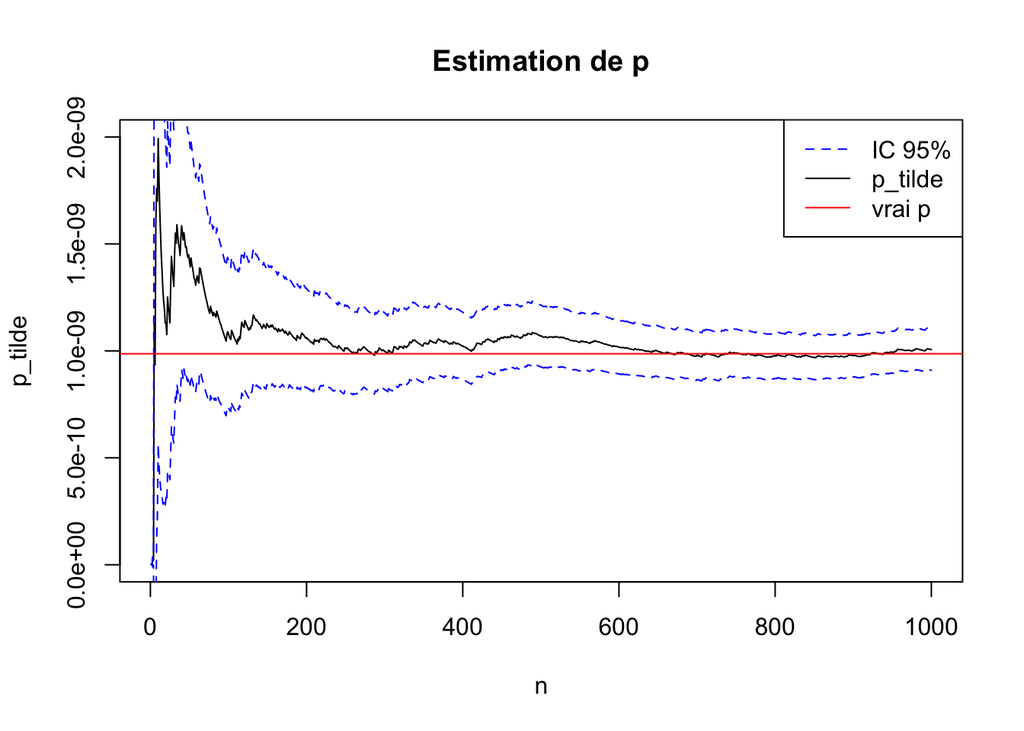

```r
n=1000
alpha=0.05
q=qnorm(1-alpha/2)
y=6+rexp(n)#On simule l'échantillonnage préférentielle (Yi)
w=exp(y-6-y^2/2)/sqrt(2*pi)
p_tilde=cumsum(w)/(1:n)
sd=sqrt(cumsum(w^2)/(1:n)-p_tilde^2)
r=q*sd/sqrt((1:n))
p_tilde_min=p_tilde-r
p_tilde_max=p_tilde+r
plot((1:n),p_tilde,type="l",ylim = c(0,2.0e-9),main = "Estimation de p", xlab = "n")
lines((1:n),p_tilde_min,type="l",lty=2,col="blue")
lines((1:n),p_tilde_max,type="l",lty=2,col="blue")
abline(h=1-pnorm(6),col="red")#la valeur vraie.
legend("topright",c("IC 95%","p_tilde","vrai p"),col = c("blue","black","red"),lty = c(2,1,1))
```

# Here comes trouble

## 2.1

C’est facil à calculer $p = 0.001$.

## 2.2

Monte-Carlo standard. On simule loi de pareto par la méthode d’inversion.

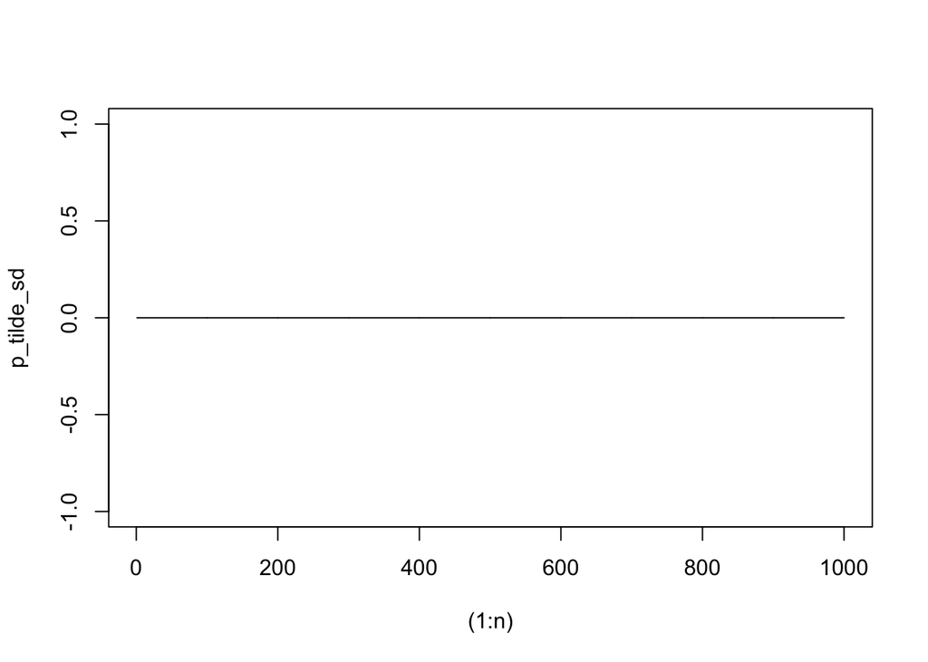

```r
p<-0.001
n<-1000
X<-((1-runif(n))^(-1/3)>10)
p_tilde_sd<-cumsum(X)/(1:n)
plot((1:n),p_tilde_sd,type = "l")
```

On peut voir que la méthode standard ne marche pas très bien.

## 2.3

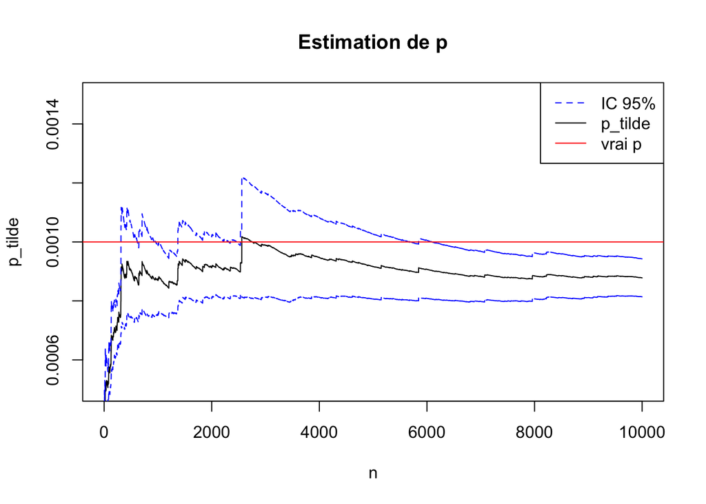

```r
n<-10000
alpha=0.05
q=qnorm(1-alpha/2)
y<-10+rexp(n)
w<-exp(y-10)*3*y^(-4)*(y>=1)
p_tilde=cumsum(w)/(1:n)
sd=sqrt(cumsum(w^2)/(1:n)-p_tilde^2)
r=q*sd/sqrt((1:n))
p_tilde_min=p_tilde-r
p_tilde_max=p_tilde+r
plot((1:n),p_tilde,type="l",ylim = c(0.0005,0.0015), main = "Estimation de p", xlab = "n")
lines((1:n),p_tilde_min,type="l",lty=2,col="blue")
lines((1:n),p_tilde_max,type="l",lty=2,col="blue")
abline(h=0.001,col="red")#la valeur vraie.
legend("topright",c("IC 95%","p_tilde","vrai p"),col = c("blue","black","red"),lty = c(2,1,1))
```

On peut voir que ça marche pas très bien cette fois, parce que ici on n’a pas de $w \cdot y$ est carré intégrable.

# 3.Somme d’exponentielles et conditionnements

## 3.1

D’après calcul,

$\begin{equation} p = 2\mathrm{e}^{-5} - \mathrm{e}^{-10} \end{equation}$

On l’estime par le monte-carlo classique.

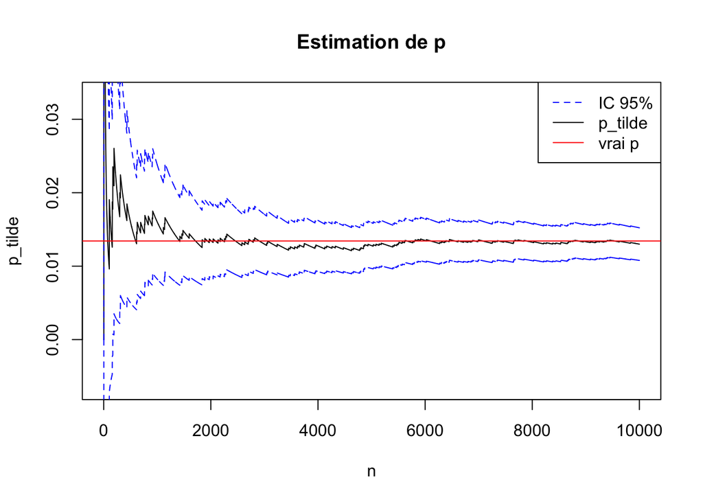

```r
n<-10000
p<-2*exp(-5)-exp(-10)
#x<--log(runif(n))
#y<--1/2*log(runif(n)/2)
#ça marche pas très bien avec méthode d'inversion. pourquoi ?
x<-rexp(n,1)
y<-rexp(n,2)
phi<-(x+y>5)
p_tilde<-cumsum(phi)/(1:n)
sd=sqrt(cumsum(phi^2)/(1:n)-p_tilde^2)
r=q*sd/sqrt((1:n))
p_tilde_min=p_tilde-r
p_tilde_max=p_tilde+r
plot((1:n),p_tilde,type="l",ylim=c(p-0.02,p+0.02), main = "Estimation de p", xlab = "n")
lines((1:n),p_tilde_min,type="l",lty=2,col="blue")
lines((1:n),p_tilde_max,type="l",lty=2,col="blue")
abline(h=p,col="red")#la valeur vraie.
legend("topright",c("IC 95%","p_tilde","vrai p"),col = c("blue","black","red"),lty = c(2,1,1))
```

Pour la variance.

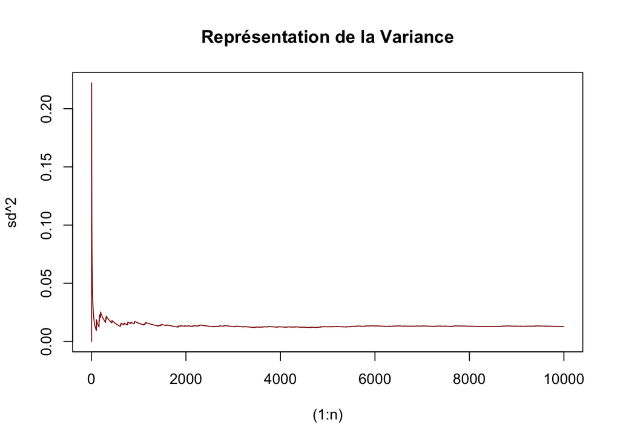

```r
plot((1:n),sd^2,type="l",col="darkred",main = "Représentation de la Variance")
```

## 3.2

S sachant Y suit une loi de densité $f_X(x) = \mathrm{e}^{-(x-y)}$

$\mathbb{E} [S] = \mathbb{E} [X] + Y$

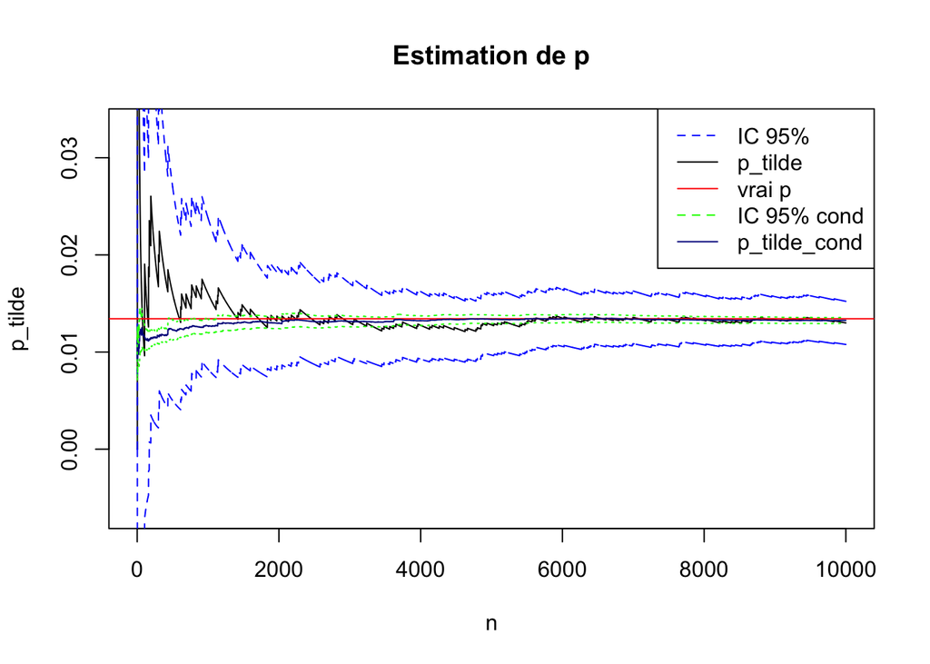

```r
phi_prime<-(y<5)*exp(y-5)+(y>5)
p_tilde_cond<-(cumsum(phi_prime))/(1:n)
sd_cond=sqrt(cumsum(phi_prime^2)/(1:n)-p_tilde_cond^2)
r_cond=q*sd_cond/sqrt((1:n))
p_tilde_min_cond=p_tilde_cond-r_cond
p_tilde_max_cond=p_tilde_cond+r_cond
plot((1:n),p_tilde,type="l",ylim=c(p-0.02,p+0.02), main = "Estimation de p", xlab = "n")
lines((1:n),p_tilde_min,type="l",lty=2,col="blue")
lines((1:n),p_tilde_max,type="l",lty=2,col="blue")
abline(h=p,col="red")#la valeur vraie.
legend("topright",c("IC 95%","p_tilde","vrai p","IC 95% cond","p_tilde_cond"),col = c("blue","black","red","green","darkblue"),lty = c(2,1,1))
lines((1:n),p_tilde_cond,type="l",col="darkblue")
lines((1:n),p_tilde_min_cond,type="l",lty=3,col="green")
lines((1:n),p_tilde_max_cond,type="l",lty=3,col="green")
```

C’est clair que la méthode avec conditionnement est bcp plus efficace que la méthode std au sens de la variance.

## 3.3

Puisque X et Y sont indépendantes, la densité de S se donne par la convolution de densité de X et Y :

$f_S(x) = 2(e^{-s}-e^{-2s}) \cdot \mathbb{1}_{s \geq 0}$

# 4.Vecteur Gaussien et exponential tilting.

## 4.1 Monte-Carlo classique

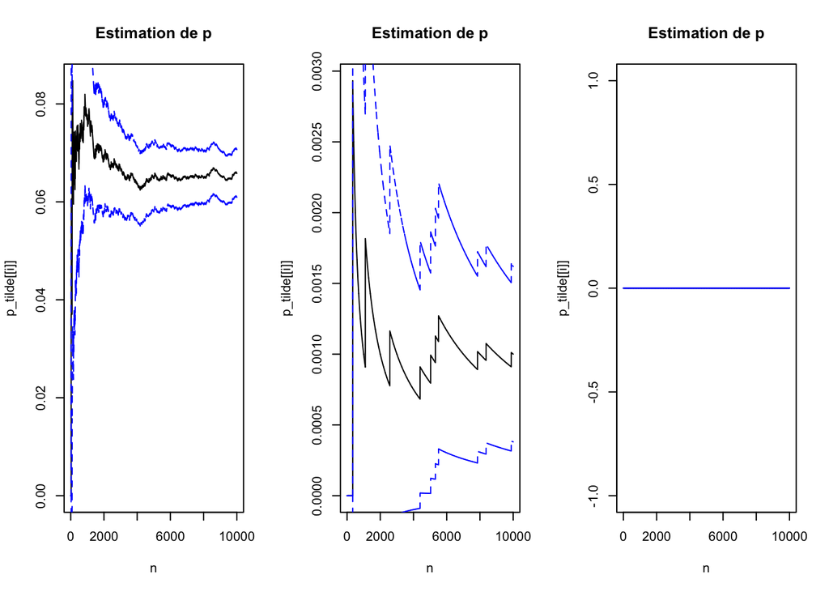

```r
library(MASS)
n=10000
alpha=0.05
q=qnorm(1-alpha/2)
gamma <- matrix(c(4,-1,-1,4),nrow = 2)
X=mvrnorm(n,rep(0,2),gamma)
x<-X[,1]
y<-X[,2]
a<-c(1,3,10)
phi<-list()
p_tilde<-list()
sd<-list()
r<-list()
p_tilde_min<-list()
p_tilde_max<-list()
par(mfrow=c(1,3))
for (i in (1:3)){
  phi[[i]]<-as.numeric(x>=a[i])*as.numeric(y>=a[i])
  p_tilde[[i]]<-cumsum(phi[[i]])/(1:n)
  sd[[i]]<-sqrt(cumsum(phi[[i]]^2)/(1:n)-p_tilde[[i]]^2)
  r[[i]]=q*sd[[i]]/sqrt((1:n))
  p_tilde_min[[i]]=p_tilde[[i]]-r[[i]]
  p_tilde_max[[i]]=p_tilde[[i]]+r[[i]]
  plot((1:n),p_tilde[[i]],type="l", main = "Estimation de p", xlab = "n")
  lines((1:n),p_tilde_min[[i]],type="l",lty=2,col="blue")
  lines((1:n),p_tilde_max[[i]],type="l",lty=2,col="blue")
  #legend("bottomright",c("IC 95%","p_tilde"),col = c("blue","black"),lty = c(2,1))
  }
```

Selon les trois plots, on peut voir que lorsque a est grand, c-à-d p est proche de 0, la Monte-Carlo standard ne marche pas bien.

## 4.2

Maximiser la densité de N(0,gamma) s’agit de minimiser une ellipses $g(x,y)=2x^2 + xy + 2y^2$

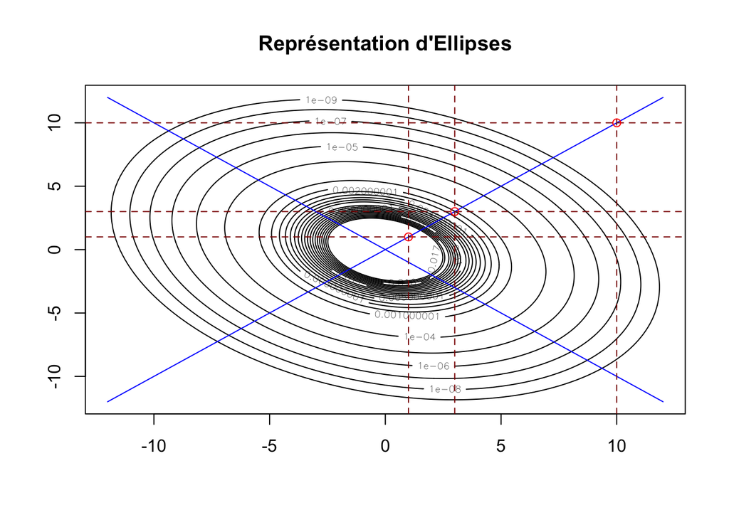

```r
f=function(x,y){exp(-(2*x^2+x*y+2*y^2)/15)/(2*pi*sqrt(15))}
g=function(x,y) 2*x^2+x*y+2*y^2
x=seq(-12,12,by=0.1)
y=x
z=outer(x,y,f)
#persp(x,y,z)

contour(x,y,z,levels =c(seq(1e-9,2e-2,by=1e-3),1e-8,1e-7,1e-6,1e-5,1e-4),main = "Représentation d'Ellipses")
lines(x,x,col="blue")
lines(x,-x,col="blue")
for (i in (1:3)){
 abline(h=a[i],col="darkred",lty=2)
 abline(v=a[i],col="darkred",lty=2)
 points(a[i],a[i],col="red")
}
```

Donc, c’est facil à vérifier que g atteint son minimum à $(a,a)$.

## 4.3

On considère une échantionnage préférée de la loi $\mathcal{N}((a,a),\Gamma)$.

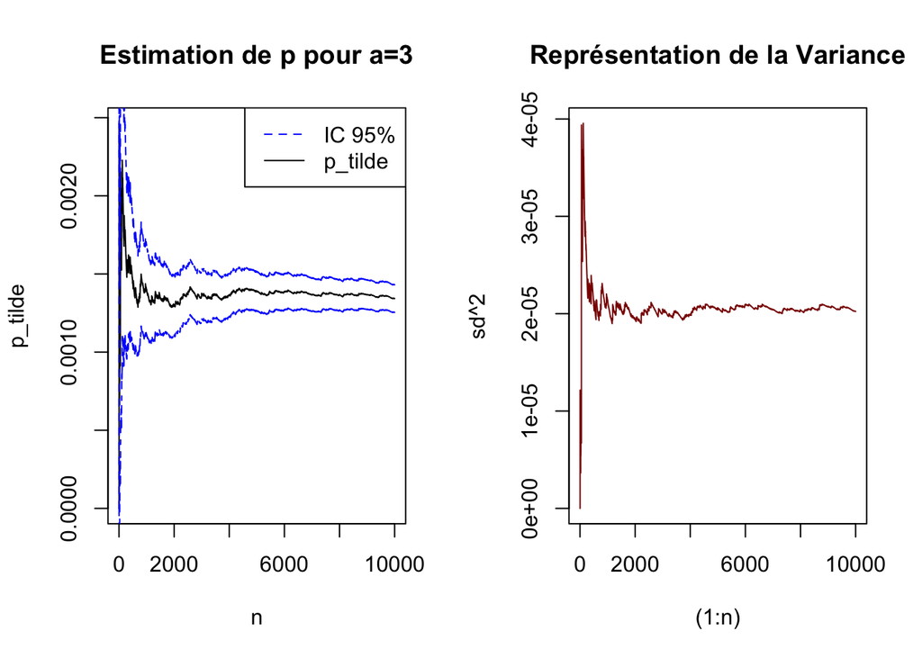

```r
library(mvtnorm)
a<-3
n<-10000
alpha=0.05
q=qnorm(1-alpha/2)
y<-rmvnorm(n,c(a,a),gamma)
w<-dmvnorm(y,c(0,0),gamma)*(y[,1]>a)*(y[,2]>a)/dmvnorm(y,c(a,a),gamma)
p_tilde<-cumsum(w)/(1:n)
sd=sqrt(cumsum(w^2)/(1:n)-p_tilde^2)
r=q*sd/sqrt((1:n))
p_tilde_min=p_tilde-r
p_tilde_max=p_tilde+r
par(mfrow=c(1,2))
plot((1:n),p_tilde,type="l", main = "Estimation de p pour a=3", xlab = "n")
lines((1:n),p_tilde_min,type="l",lty=2,col="blue")
lines((1:n),p_tilde_max,type="l",lty=2,col="blue")
legend("topright",c("IC 95%","p_tilde"),col = c("blue","black"),lty = c(2,1))
plot((1:n),sd^2,col="darkred",type = "l",main = "Représentation de la Variance")
```

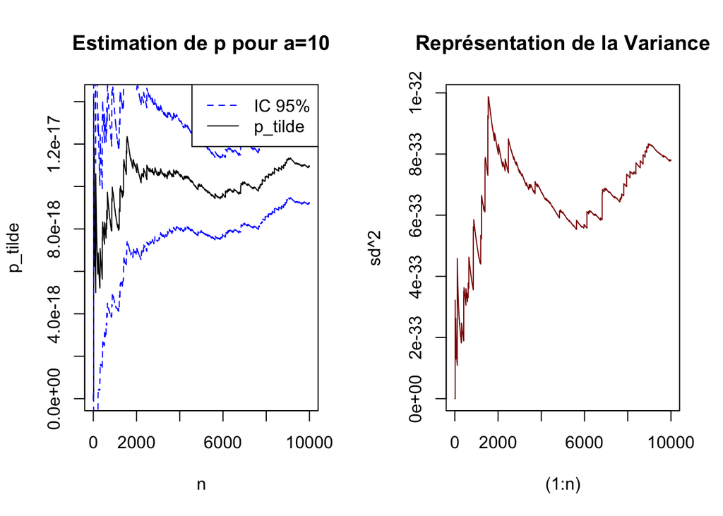

```r
a<-10

m0<-c(a,a)

#on étudie l'ech pour les paramètres différents.
y<-rmvnorm(n,m0,gamma)
w<-dmvnorm(y,c(0,0),gamma)*(y[,1]>a)*(y[,2]>a)/dmvnorm(y,m0,gamma)
p_tilde<-cumsum(w)/(1:n)
sd=sqrt(cumsum(w^2)/(1:n)-p_tilde^2)
r=q*sd/sqrt((1:n))
p_tilde_min=p_tilde-r
p_tilde_max=p_tilde+r
par(mfrow=c(1,2))
plot((1:n),p_tilde,type="l", main = "Estimation de p pour a=10", xlab = "n")
lines((1:n),p_tilde_min,type="l",lty=2,col="blue")
lines((1:n),p_tilde_max,type="l",lty=2,col="blue")
legend("topright",c("IC 95%","p_tilde"),col = c("blue","black"),lty = c(2,1))

plot((1:n),sd^2,col="darkred",type = "l",main = "Représentation de la Variance")
```

On peut voir que après l’utilisation de “Important sampling”, l’Estimation pour a=10 devient plus stable.

## 4.4

### cas1 : si $(x_0,y_0)$ est loin de $(a,a)$

$(x_0,y_0) = (a+10,a+10)$

$\delta = 1$

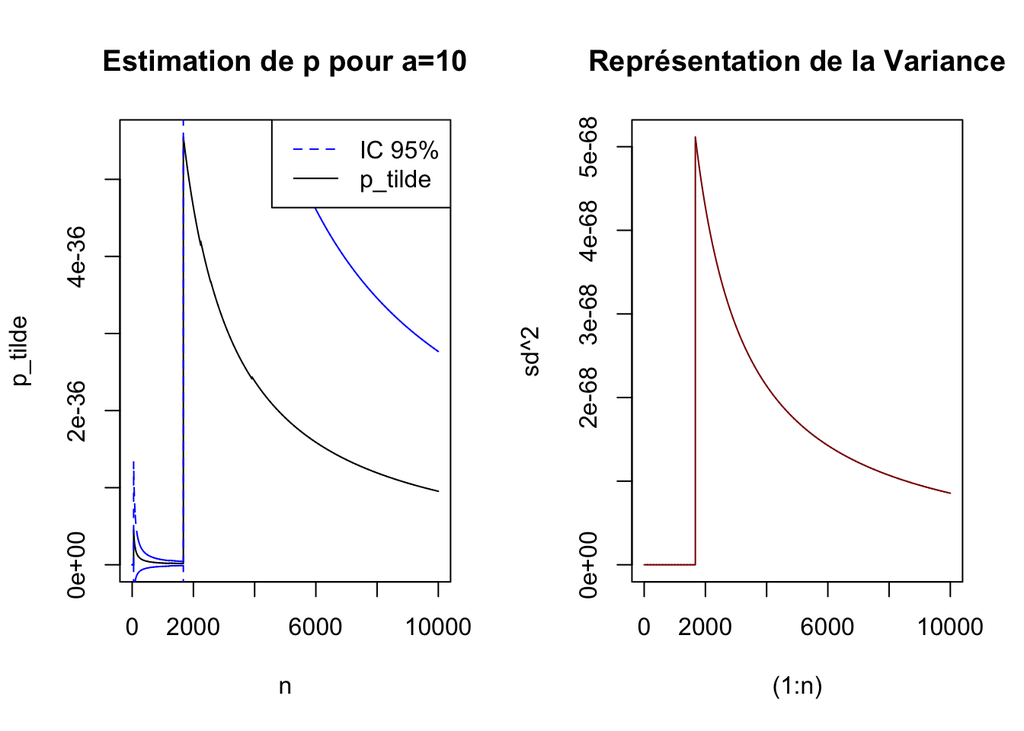

L’estimation devient instable.

### cas2 : si delta est grand.

$(x_0,y_0) = (a+10,a+10)$

$\delta = 10$

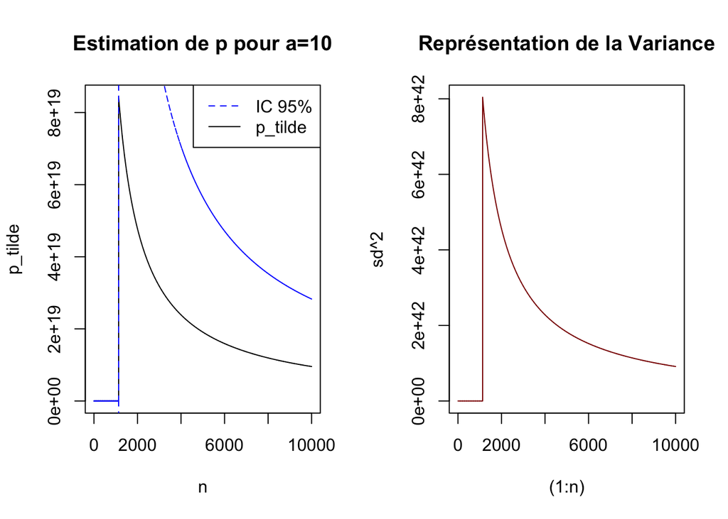

La variance de l’estimation devient trop grande lorsque delta est grande.

### cas3 : si delta est trop petit.

$(x_0,y_0) = (a,a)$

$\delta = 0.01$

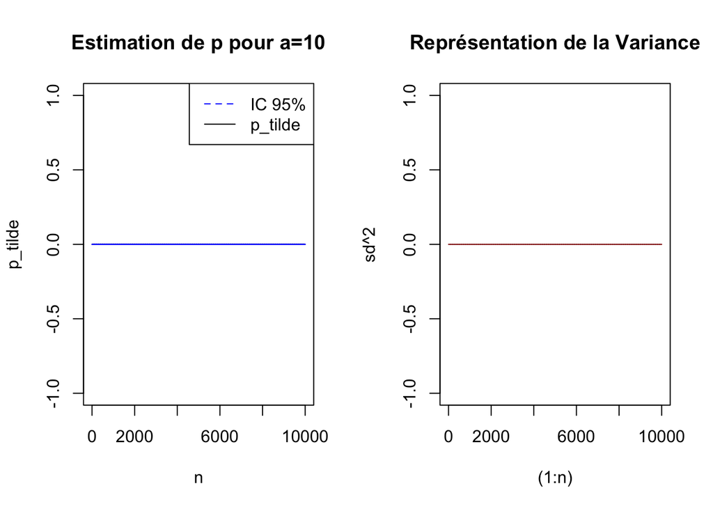

On peut voir que dans cette situation, l’estimation est impossible comme dans le cas monte-carlo standard.

### cas4 : si delta est ajusté.

$(x_0,y_0) = (a,a)$

$\delta = 0.1$

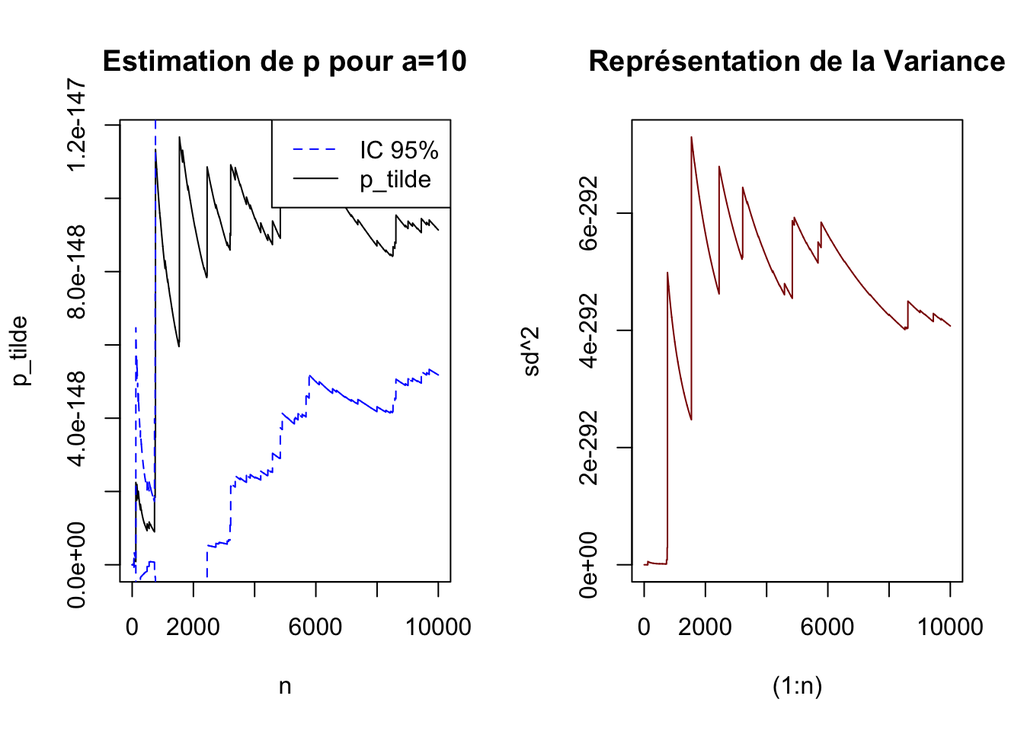

Dans ce cas, la variance est bcp plus petit que au cas où $\delta = 1$, et de plus, on n’a pas vu de phénomène dans le cas monte-carlo standard. Alors, c’est un bon choix pour l’estimer.

# 5.Variables antithétiques.

## 5.1 & 5.2

On va regarder $I = \int_0^1 \mathrm{e}^u \mathrm{d}u$ comme $\mathbb{E}[\varphi (X)]$ où X suit une loi uniforme sur (0,1) et $\varphi (x) = \mathrm{e}^x$.

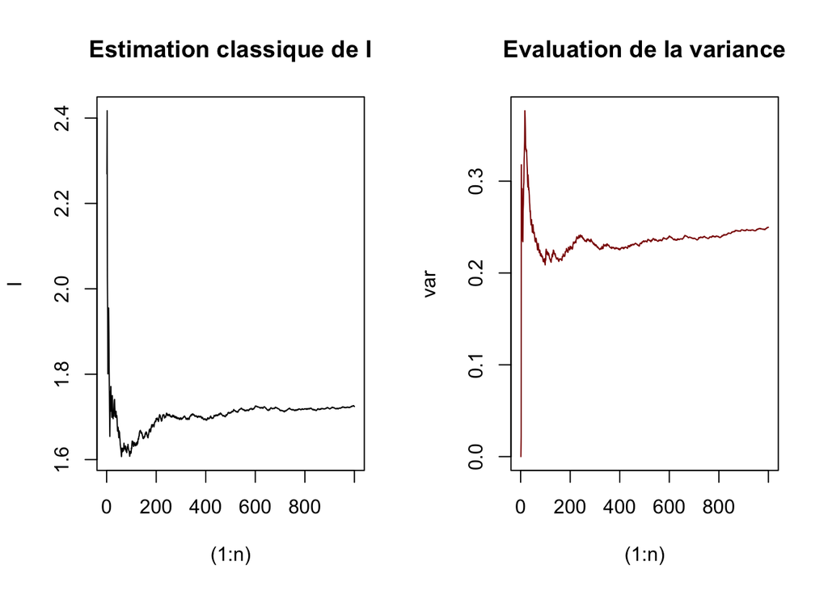

```r
n<-1000
x<-runif(n)
phi<-exp(x)
I<-cumsum(phi)/(1:n)
var<-cumsum(phi^2)/(1:n)-I^2
par(mfrow=c(1,2))
plot((1:n),I,main = "Estimation classique de I",type = "l")
plot((1:n),var,main = "Evaluation de la variance",col="darkred",type="l")
```

## 5.3

Par les calculs, on a théoriquement pour l’estiamteur de monte-carlo standard :

$I = \mathrm{e} - 1$

et pour l’estimateur de variables antithétiques :

$\tilde{I} = I$

$\begin{equation} \mathrm{s}^2 = \frac{1}{2}\mathrm{e}^2-(\mathrm{e}-1)^2 \approx 0.74 \end{equation}$

## 5.4

$\mathbb{E}[X_c] = \mathbb{E}[\mathrm{e}^U + c(U-\frac{1}{2}) ] = I$

D’après calculs, on obtient :

$\mathbb{V}[U] = \frac{1}{12}$

$\mathrm{Cov}[\mathrm{e}^U,c(U-\frac{1}{2})] = c$

alors,

$\mathbb{V}[X_c] = \frac{1}{12} c^2 + c +2(\mathrm{e}-1)$

$c^{\star} = -6$

$\mathbb{V}[X_{c^{\star}}] = 2(\mathrm{e}-1) - 3 \approx 0.44 < \mathrm{s}^2 \approx 0.74$

C’est-à-d, si on compare cet estimateur et l’estimateur de variables antithétiques, il est plus prècis par rapport à la variance, mais plus coûteux par rapport au temps pour calculs.

# 6.Preuve par couplage de l’inégarité de covariance de Tchebychev.

## 6.1

Puisque$X \perp\!\!\perp X'$, On a :

$\mathbb{E}(\varphi(X)-\varphi(X')) = 0 \;\;et\;\; \mathbb{E}(\psi(X)-\psi(X')) = 0$

alors,

$\mathrm{Cov}(\varphi(X)-\varphi(X'),\psi(X)-\psi(X')) = \mathbb{E}[(\varphi(X)-\varphi(X'))(\psi(X)-\psi(X'))]$

de plus, comme $\varphi(\cdot)(resp. \psi(\cdot))$ est croissante(resp. décroissante), On a :

$(\varphi(X)-\varphi(X'))(\psi(X)-\psi(X')) \leq 0, \;\;\forall X,X' \in \mathbb{R}$

alors,

$\mathrm{Cov}(\varphi(X)-\varphi(X'),\psi(X)-\psi(X')) = \mathbb{E}[(\varphi(X)-\varphi(X'))(\psi(X)-\psi(X'))] \leq 0$

## 6.2

Puisque$X \perp\!\!\perp X'$, On a :

$\mathrm{Cov}((\varphi(X)-\varphi(X'))(\psi(X)-\psi(X'))) = \mathrm{Cov}(\phi(X),\psi(X))+\mathrm{Cov}(\phi(X'),\psi(X'))$

Or $X \sim X'$ :

$\mathrm{Cov}((\varphi(X)-\varphi(X'))(\psi(X)-\psi(X'))) = 2\mathrm{Cov}(\phi(X),\psi(X))$

## 6.3

Puisque $h(X) \sim X$,

$\mathbb{V}(\frac{\varphi(X)+\varphi(h(X))}{2}) = \frac{1}{2}\mathbb{V}(\varphi(X)) + \frac{1}{4}\mathrm{Cov}(\varphi(X),\varphi(h(X)))$

Or, $\varphi (\cdot)$ est monotone et $h(\cdot)$ est décroissante, alors, il y a une fonction croissante et une décroissante entre $\varphi(\cdot)$ et $\varphi(h(\cdot)).$ Alors, d’après ce qu’on a déjà montré,

$\mathrm{Cov}(\varphi(X),\varphi(h(X))) \leq 0$

C’est-à-dire,

$\mathbb{V}(\frac{\varphi(X)+\varphi(h(X))}{2}) \leq \frac{1}{2}\mathbb{V}(\phi(X))$

## 6.4

Lorsque $X \sim \mathcal{N}(0,1)$, on a $X \sim -X$.

Alors, on considère $\varphi(x) = \mathrm{e}^x$ et $h(x) = -x$.

C’est clair que $\varphi$ est croissante et $h$ est décroissante.

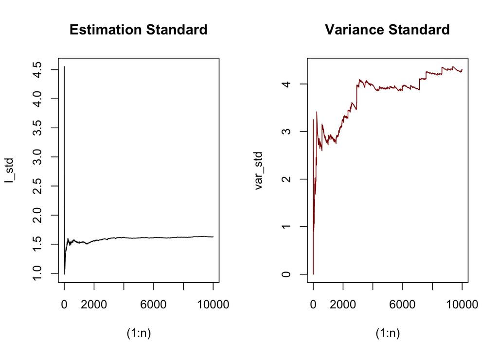

```r
n<-10000
X<-rnorm(n)
I_std<-cumsum(exp(X))/(1:n)
var_std<-cumsum(exp(2*X))/(1:n)-I_std^2

I_adjusted<-cumsum((exp(X)+exp(-X))/2)/(1:n)
var_adjusted<-cumsum( (   (exp(X)+exp(-X))/2 )^2  )/(1:n) - I_adjusted^2

par(mfrow=c(1,2))

plot((1:n),I_std,main = "Estimation Standard",type = "l")
plot((1:n),var_std,main = "Variance Standard",col="darkred",type = "l")
```

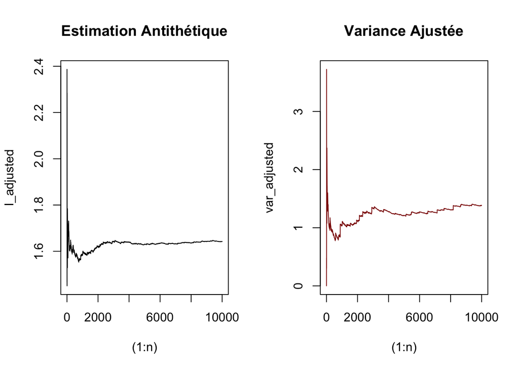

```r
plot((1:n),I_adjusted,main = "Estimation Antithétique",type = "l")
plot((1:n),var_adjusted, main = "Variance Ajustée",col="darkred",type = "l")
```

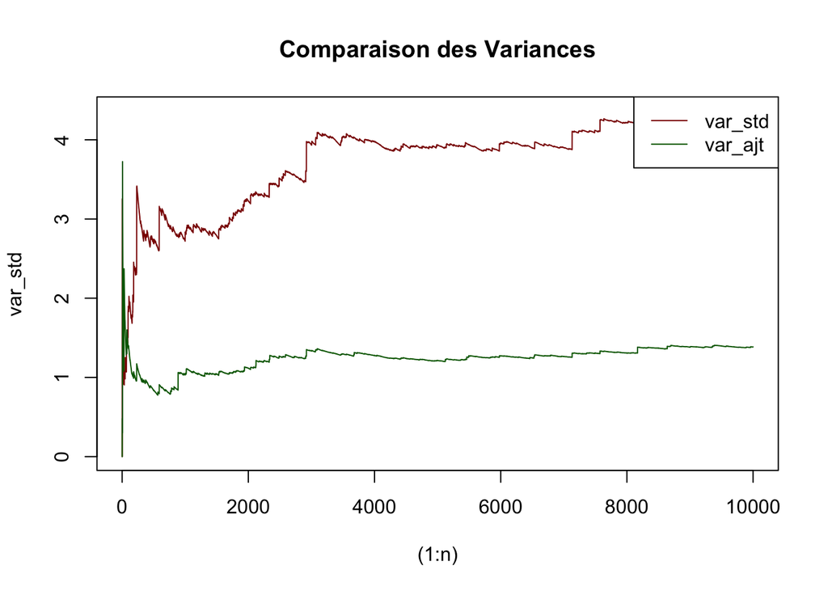

```r
par(mfrow=c(1,1))

plot((1:n),var_std,main = "Comparaison des Variances",col="darkred",type = "l")
lines((1:n),var_adjusted,col="darkgreen",type = "l")
legend("topright",c("var_std","var_ajt"),col = c("darkred","darkgreen"),lty = c(1,1))
```

On peut voir que cette méthode est plus efficace au sens de la variance.

## 6.5

On va comparaison la méthode d’antithétique et la méthode conditionnelle.

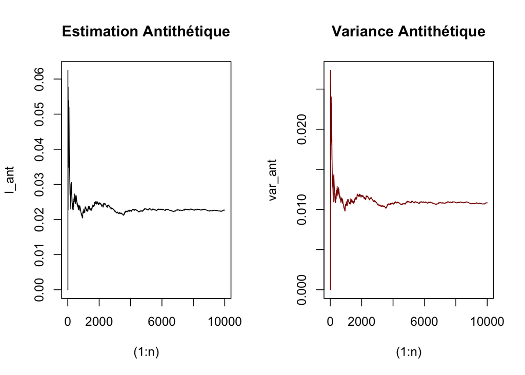

```r
n<-10000
u<-runif(n)
v<-runif(n)
phi<-(-log(u)-0.5*log(v)+0.5>=5)
psi<-(-log(1-u)-0.5*log(1-v)+0.5>=5)
I_ant<-cumsum((phi+psi)/2)/(1:n)
var_ant<-cumsum(((phi+psi)/2)^2)/(1:n)-I_ant^2
par(mfrow=c(1,2))
plot((1:n),I_ant,main = "Estimation Antithétique",type = "l")
plot((1:n),var_ant, main = "Variance Antithétique",col="darkred",type = "l")
```

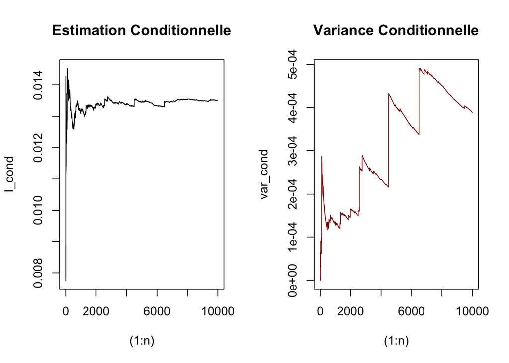

```r
x<-rexp(n,1)
y<-rexp(n,2)
phi_prime<-(y<5)*exp(y-5)+(y>5)
I_cond<-(cumsum(phi_prime))/(1:n)
var_cond<-cumsum(phi_prime^2)/(1:n)-I_cond^2
plot((1:n),I_cond,main = "Estimation Conditionnelle",type = "l")
plot((1:n),var_cond, main = "Variance Conditionnelle",col="darkred",type = "l")
```

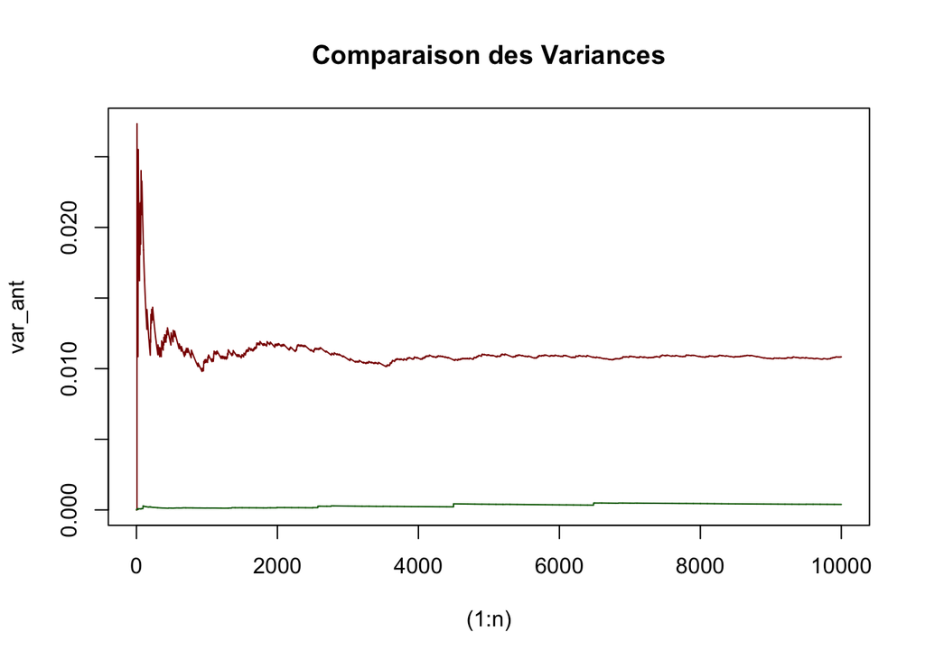

```r
par(mfrow=c(1,1))
plot((1:n),var_ant, main = "Comparaison des Variances",col="darkred",type = "l")
lines((1:n),var_cond,col="darkgreen",type = "l")
```